# 2026 Power 4 Swing Decision Report

A count-adjusted hitter decision model for Power 4 college baseball

Author

Andy Lucas

# Project Overview

This project builds a count-adjusted swing-decision model for 2026 Power 4 college baseball hitters. The goal is to separate process from outcome: did the hitter choose the right pitch to swing at before contact quality, batted-ball luck, or game result entered the evaluation?

This report evaluates hitter decision quality across the 2026 Power 4 college baseball season. It is built around a simple baseball question: given the count and pitch location, did the hitter make a decision that created value?

The report is split into two views. The full dataset view includes all pitches seen by Power 4 hitters in the file. The P4 vs P4 view only includes games where both teams were Power 4 programs, creating a cleaner competition-adjusted lens. Together, those views separate broad season-long approach from decisions made against comparable opponents.

All leaderboards are interactive. Each table opens to 20 players or teams per page, while the full qualified pool remains available through pagination, sorting, searching, column filters, and export buttons.

## Methodology

The decision score is built from a count-specific attack zone and a fixed swing/take scoring chart.

Each pitch is assigned to one of four zones:

- `Heart`: the count-specific damage zone
- `Paint`: the edge of the strike zone and the area just off the plate
- `Chase`: clear balls that are still close enough to tempt swings
- `Waste`: pitches far enough from the strike zone that hitters should almost never swing

For two-strike counts, the heart zone expands to the entire strike zone. For non-two-strike counts, the heart zone expands or contracts by count. Three-ball, zero-strike counts are removed because many hitters are taking automatically.

The count changes the size of the heart zone, but the value of each zone stays consistent. This keeps count adjustment in one place and makes the model easier to explain. All pitch-level decision scores are kept on a `-3` to `3` scale.

`Chase%` is calculated using the standard plate-discipline definition: swings at pitches outside the strike zone divided by total pitches outside the strike zone. This is separate from the model’s `Chase` and `Waste` scoring zones, which are still used to assign pitch-level decision values.

## Executive Summary

480,600Full-schedule scored pitches

297,017P4 vs P4 scored pitches

417Qualified full-schedule hitters

439Qualified P4 vs P4 hitters

Dee KennedyTop P4 vs P4 hitter by decision score

North Carolina Tar HeelsTop P4 vs P4 team by decision score

The current model scores 480,600 tracked pitches in the full Power 4 hitter view and 297,017 tracked pitches in the P4 vs P4 view. The average decision score is 0.943 in the full dataset and 0.925 in P4 vs P4 games.

The most valuable decision profile is selective aggression. Hitters are rewarded for swinging at heart pitches, receiving partial credit for competing on the paint, and getting penalized for expanding into chase or waste areas. Takes are graded the opposite way: taking heart pitches is punished, while taking chase and waste pitches is rewarded.

This structure makes the model especially useful for player development conversations. A high score points to a hitter whose approach is aligned with the count and pitch location. A lower score does not automatically mean the hitter lacks talent; it points to a decision pattern worth reviewing with video, count context, and opponent plan.

## Dataset Footprint

Dataset Check

| Dataset | Pitches | Hitters | Teams | Games | Missing Scores |
| --- | --- | --- | --- | --- | --- |
| Full P4 Schedule Data | 480600 | 1061 | 61 | 2161 | 0 |
| P4 vs P4 Only | 297017 | 1006 | 61 | 984 | 0 |

Pitch Calls in Full Dataset

| Pitch Call | Pitches |
| --- | --- |
| BallCalled | 183148 |
| InPlay | 81649 |
| StrikeCalled | 79873 |
| FoulBallNotFieldable | 74539 |
| StrikeSwinging | 51839 |
| HitByPitch | 4050 |
| BallinDirt | 3704 |
| FoulBallFieldable | 1737 |
| BallIntentional | 32 |
| FoulBall | 29 |

# Full-Schedule Results

The full dataset section is the broadest read on each Power 4 hitter’s approach. It includes games against every opponent in the file, so it is best used as a season-long baseline. Because this view includes non-P4 opponents, it can be influenced by differences in command, stuff quality, and game context.

## Full Dataset Hitter Leaderboard

| Hitter | Team | Pitches | Decision Score | Total Score | Chase% | Heart Swing% | Heart Take% | 2K Score | 0-Ball Score | Ahead Score | Behind Score | Avg EV | Hard-Hit% | Profile |
| --- | --- | --- | --- | --- | --- | --- | --- | --- | --- | --- | --- | --- | --- | --- |
| Dee Kennedy | Kansas State Wildcats | 832 | 1.251201923076923 | 1041 | 0.2064516129032258 | 0.844 | 0.156 | 1.661971830985915 | 1.16120218579235 | 1.241509433962264 | 1.398550724637681 | 86.90485260089686 | 0.3811659192825112 | Selective Attacker |
| Armani Guzman | West Virginia Mountaineers | 795 | 1.237735849056603 | 984 | 0.2526997840172786 | 0.8620689655172413 | 0.1379310344827586 | 1.680288461538461 | 1.085227272727272 | 1.235887096774194 | 1.462121212121212 | 81.2771483898305 | 0.2245762711864407 | Balanced |
| Yomar Carreras | Rutgers Scarlet Knights | 714 | 1.210084033613446 | 864 | 0.3981481481481481 | 0.9293478260869565 | 0.07065217391304347 | 1.236263736263736 | 1.314199395770393 | 1.106382978723404 | 1.31578947368421 | 82.12324856666666 | 0.2266666666666667 | Aggressive Expander |
| Chase Krewson | Rutgers Scarlet Knights | 831 | 1.182912154031288 | 983 | 0.3023255813953488 | 0.8744186046511628 | 0.1255813953488372 | 1.47071129707113 | 1.07372654155496 | 1.117647058823529 | 1.361233480176212 | 80.52160574144487 | 0.2243346007604563 | Balanced |
| Owen Hull | North Carolina Tar Heels | 881 | 1.175368898978434 | 1035.5 | 0.2323809523809524 | 0.8132780082987552 | 0.1867219917012448 | 1.495327102803738 | 1.05859375 | 1.171480144404332 | 1.352112676056338 | 85.96123654135339 | 0.3157894736842105 | Selective Attacker |
| Kolby Branch | Georgia Bulldogs | 929 | 1.172766415500537 | 1089.5 | 0.2650822669104205 | 0.8730769230769231 | 0.1269230769230769 | 1.424561403508771 | 1.14119170984456 | 1.052264808362369 | 1.386831275720165 | 87.569990390625 | 0.40234375 | Balanced |
| Charlie Sutherland | Minnesota Golden Gophers | 659 | 1.163884673748103 | 767 | 0.2954545454545455 | 0.8707865168539326 | 0.1292134831460674 | 1.497297297297297 | 1.054577464788733 | 0.9782608695652175 | 1.244117647058824 | 83.87533195454546 | 0.3272727272727273 | Balanced |
| Tracer Lopez | Texas Tech Red Raiders | 891 | 1.161054994388327 | 1034.5 | 0.2859813084112149 | 0.8940677966101694 | 0.1059322033898305 | 1.455156950672646 | 1.059343434343435 | 1.245247148288973 | 1.147321428571428 | 81.25721360655737 | 0.1967213114754098 | Balanced |
| Brady Neal | Alabama Crimson Tide | 795 | 1.159748427672955 | 922 | 0.2222222222222222 | 0.815668202764977 | 0.184331797235023 | 1.489177489177489 | 1.05223880597015 | 1.075313807531382 | 1.305 | 83.72421736842105 | 0.3205741626794258 | Selective Attacker |
| Daniel Cuvet | Miami Hurricanes | 700 | 1.159285714285714 | 811.5 | 0.2699530516431925 | 0.8688524590163934 | 0.1311475409836066 | 1.532608695652174 | 1.020634920634921 | 1.276497695852535 | 1.387978142076503 | 85.013766146789 | 0.3532110091743119 | Balanced |

[output cut: 407 more lines]

## Full Dataset Team Leaderboard

| Team | Pitches | Hitters | Decision Score | Total Score | Chase% | Heart Swing% | Heart Take% | 2K Score | Avg EV | Hard-Hit% |
| --- | --- | --- | --- | --- | --- | --- | --- | --- | --- | --- |
| North Carolina Tar Heels | 8064 | 16 | 1.024987599206348 | 8265.5 | 0.2611373434613016 | 0.7851043643263758 | 0.2148956356736243 | 1.298462255358807 | 84.60524907036248 | 0.3087420042643923 |
| Arizona State Sun Devils | 7882 | 18 | 1.008880994671403 | 7952 | 0.3016366273047442 | 0.7957884427032321 | 0.2042115572967679 | 1.246373186593297 | 85.77597964594483 | 0.323589954713874 |
| Alabama Crimson Tide | 7988 | 17 | 0.9997496244366583 | 7986 | 0.2542726135889954 | 0.7709417889256981 | 0.2290582110743019 | 1.252477380439463 | 83.42954717568215 | 0.2886548587841072 |
| Tennessee Volunteers | 8183 | 18 | 0.9995722840034225 | 8179.5 | 0.3147308223230132 | 0.8102294455066922 | 0.1897705544933078 | 1.157687253613666 | 84.7816112867647 | 0.3120915032679739 |
| Arizona Wildcats | 6977 | 19 | 0.9991400315321765 | 6971 | 0.2942028985507246 | 0.7840327533265097 | 0.2159672466734903 | 1.306427870461238 | 83.65904869041383 | 0.2750130958617077 |
| Texas Tech Red Raiders | 8278 | 18 | 0.9988523798018839 | 8268.5 | 0.2678426601784266 | 0.7776773610483506 | 0.2223226389516493 | 1.314914645103324 | 85.84367065868264 | 0.3437125748502994 |
| Mississippi State Bulldogs | 8584 | 18 | 0.9916123019571282 | 8512 | 0.2799231508165226 | 0.7852787456445993 | 0.2147212543554007 | 1.264950166112957 | 84.66892538742394 | 0.311156186612576 |
| Kansas Jayhawks | 8136 | 14 | 0.9858652900688301 | 8021 | 0.2608517608517609 | 0.7699156513589503 | 0.2300843486410497 | 1.321537789427699 | 84.80022603563474 | 0.311358574610245 |
| Utah Utes | 7501 | 16 | 0.9852019730702548 | 7390 | 0.300259965337955 | 0.7882836587872559 | 0.2117163412127441 | 1.176991150442478 | 82.42451173392462 | 0.2576496674057649 |
| West Virginia Mountaineers | 7848 | 17 | 0.9840723751274202 | 7723 | 0.2477516059957174 | 0.765172735760971 | 0.2348272642390289 | 1.355183635518363 | 84.23427311862837 | 0.2910101946246524 |

[output cut: 51 more lines]

## Full Dataset Count Trends

[interactive chart not shown]

## Full Dataset Decision Profile Plot

[interactive chart not shown]

# P4 vs P4 Results

The P4 vs P4 section is the cleaner comparison group. It trims the sample to matchups where both teams are Power 4 programs, which makes the leaderboard more useful for evaluating how a hitter’s decision quality holds up against stronger and more comparable pitching.

## P4 vs P4 Hitter Leaderboard

| Hitter | Team | Pitches | Decision Score | Total Score | Chase% | Heart Swing% | Heart Take% | 2K Score | 0-Ball Score | Ahead Score | Behind Score | Avg EV | Hard-Hit% | Profile |
| --- | --- | --- | --- | --- | --- | --- | --- | --- | --- | --- | --- | --- | --- | --- |
| Dee Kennedy | Kansas State Wildcats | 562 | 1.263345195729537 | 710 | 0.2131147540983606 | 0.8547486033519553 | 0.1452513966480447 | 1.647651006711409 | 1.216269841269841 | 1.199438202247191 | 1.469178082191781 | 86.3138084868421 | 0.375 | Selective Attacker |
| Armani Guzman | West Virginia Mountaineers | 466 | 1.238197424892704 | 577 | 0.24 | 0.8671875 | 0.1328125 | 1.70353982300885 | 1.125 | 1.085820895522388 | 1.44672131147541 | 82.0605611904762 | 0.2380952380952381 | Selective Attacker |
| Kyle Schupmann | Illinois Fighting Illini | 528 | 1.21969696969697 | 644 | 0.2360655737704918 | 0.8766233766233766 | 0.1233766233766234 | 1.427215189873418 | 1.160337552742616 | 1.223333333333333 | 1.327702702702703 | 83.34293818181818 | 0.2792207792207792 | Selective Attacker |
| Mac Moyer | Nebraska Cornhuskers | 687 | 1.189956331877729 | 817.5 | 0.2164705882352941 | 0.8378378378378378 | 0.1621621621621622 | 1.703488372093023 | 1.036713286713287 | 1.142857142857143 | 1.537974683544304 | 85.25061482587064 | 0.2985074626865671 | Selective Attacker |
| Yomar Carreras | Rutgers Scarlet Knights | 414 | 1.188405797101449 | 492 | 0.4008264462809917 | 0.9298245614035088 | 0.07017543859649122 | 1.287610619469027 | 1.324742268041237 | 1.080952380952381 | 1.336448598130841 | 82.18368988571429 | 0.2285714285714286 | Aggressive Expander |
| Cameron Gurney | Utah Utes | 503 | 1.187872763419483 | 597.5 | 0.3410596026490066 | 0.8857142857142857 | 0.1142857142857143 | 1.319018404907975 | 1.125 | 1.090909090909091 | 1.127450980392157 | 84.20638952380952 | 0.2645502645502645 | Balanced |
| Brady Neal | Alabama Crimson Tide | 490 | 1.186734693877551 | 581.5 | 0.2093862815884477 | 0.8321167883211679 | 0.1678832116788321 | 1.523026315789474 | 1.180412371134021 | 0.9761904761904762 | 1.483333333333333 | 85.1194508 | 0.32 | Selective Attacker |
| Chase Krewson | Rutgers Scarlet Knights | 462 | 1.180735930735931 | 545.5 | 0.3090277777777778 | 0.8907563025210085 | 0.1092436974789916 | 1.444444444444444 | 1.071428571428572 | 1.063025210084034 | 1.398550724637681 | 78.376451292517 | 0.1768707482993197 | Balanced |
| Daniel Cuvet | Miami Hurricanes | 383 | 1.177545691906005 | 451 | 0.3014354066985646 | 0.8728813559322034 | 0.1271186440677966 | 1.584210526315789 | 1.067708333333333 | 1.125 | 1.436363636363637 | 85.56925962406015 | 0.3458646616541353 | Balanced |
| Charlie Sutherland | Minnesota Golden Gophers | 436 | 1.165137614678899 | 508 | 0.3003802281368821 | 0.8898305084745762 | 0.1101694915254237 | 1.464285714285714 | 1.08288770053476 | 0.8826086956521743 | 1.178260869565217 | 83.93078202702702 | 0.3310810810810811 | Balanced |

[output cut: 429 more lines]

## P4 vs P4 Team Leaderboard

| Team | Pitches | Hitters | Decision Score | Total Score | Chase% | Heart Swing% | Heart Take% | 2K Score | Avg EV | Hard-Hit% |
| --- | --- | --- | --- | --- | --- | --- | --- | --- | --- | --- |
| North Carolina Tar Heels | 5212 | 16 | 1.019474290099771 | 5313.5 | 0.2700258397932817 | 0.7921428571428571 | 0.2078571428571429 | 1.307097680955727 | 84.51822770696452 | 0.3134034165571616 |
| West Virginia Mountaineers | 4825 | 17 | 0.9878756476683941 | 4766.5 | 0.2593368237347295 | 0.7640949554896143 | 0.2359050445103858 | 1.355825958702065 | 84.48741754916793 | 0.2934947049924357 |
| Kansas Jayhawks | 5075 | 13 | 0.9866009852216748 | 5007 | 0.2811776381078399 | 0.7795620437956204 | 0.2204379562043796 | 1.295454545454545 | 85.23026266805267 | 0.3201663201663202 |
| Alabama Crimson Tide | 4614 | 16 | 0.981577806675338 | 4529 | 0.2731939860652732 | 0.7705179282868526 | 0.2294820717131474 | 1.239130434782608 | 83.82449663398693 | 0.2843137254901961 |
| Wake Forest Demon Deacons | 4583 | 15 | 0.9783984289766554 | 4484 | 0.2563729060451566 | 0.7639000805801772 | 0.2360999194198227 | 1.182001614205003 | 85.1058292457421 | 0.300081103000811 |
| BYU Cougars | 4509 | 14 | 0.9763805721889539 | 4402.5 | 0.2883617494440326 | 0.7822514379622021 | 0.2177485620377979 | 1.179273827534039 | 84.91798156991005 | 0.30335241210139 |
| Michigan State Spartans | 4795 | 16 | 0.9650677789363932 | 4627.5 | 0.2921469740634006 | 0.7880149812734082 | 0.2119850187265918 | 1.204918032786885 | 82.69742287634409 | 0.2486559139784946 |
| Utah Utes | 4655 | 14 | 0.9640171858216975 | 4487.5 | 0.3158640226628895 | 0.7876602564102564 | 0.2123397435897436 | 1.11680801850424 | 82.51679427068724 | 0.2454417952314165 |
| Arizona Wildcats | 4434 | 18 | 0.9633513757329731 | 4271.5 | 0.3023872679045093 | 0.773095623987034 | 0.226904376012966 | 1.26194086429113 | 83.54231113998324 | 0.2665549036043587 |
| Arizona State Sun Devils | 5027 | 15 | 0.9631987268748742 | 4842 | 0.3142489546477967 | 0.7788089713843774 | 0.2211910286156226 | 1.214070729872085 | 86.22526944369973 | 0.3290884718498659 |

[output cut: 51 more lines]

## P4 vs P4 Count Trends

[interactive chart not shown]

## P4 vs P4 Decision Profile Plot

[interactive chart not shown]

# Full Dataset vs P4 vs P4 Comparison

This section compares each hitter’s full-schedule decision profile to his P4 vs P4 profile. Players who improve in the P4 sample may be showing an approach that travels well against better competition. Players who fall off are not automatically poor decision-makers, but they are worth reviewing because the stricter opponent pool may expose different chase, take, or attack patterns.

## Hitter Comparison

| Hitter | Team | Full Pitches | P4 Pitches | Full Score | P4 Score | Score Change | Full Chase% | P4 Chase% | Full Heart Swing% | P4 Heart Swing% | Chase Change | Heart Swing Change |
| --- | --- | --- | --- | --- | --- | --- | --- | --- | --- | --- | --- | --- |
| Will Johannes | Illinois Fighting Illini | 620 | 373 | 0.6774193548387097 | 0.804289544235925 | 0.1268701893972153 | 0.3079019073569482 | 0.3087557603686636 | 0.6285714285714286 | 0.6851851851851852 | 0.0008538530117153664 | 0.05661375661375667 |
| Andrew Lamb | USC Trojans | 691 | 378 | 1.010853835021708 | 1.12962962962963 | 0.1187757946079213 | 0.319047619047619 | 0.2914798206278027 | 0.7857142857142857 | 0.8207547169811321 | -0.02756779841981633 | 0.03504043126684642 |
| Blake Schaaf | Wake Forest Demon Deacons | 682 | 389 | 1.005865102639295 | 1.101542416452442 | 0.09567731381314659 | 0.2116788321167883 | 0.2197309417040359 | 0.7445652173913043 | 0.7704918032786885 | 0.008052109587247558 | 0.02592658588738417 |
| Enzo Infelise | Cincinnati Bearcats | 834 | 427 | 0.8489208633093526 | 0.9437939110070251 | 0.09487304769767257 | 0.3154761904761905 | 0.3256704980842912 | 0.7347826086956522 | 0.75 | 0.01019430760810069 | 0.01521739130434785 |
| Carson Kerce | Georgia Tech Yellow Jackets | 854 | 571 | 0.9900468384074943 | 1.080560420315236 | 0.09051358190774184 | 0.241014799154334 | 0.2203947368421053 | 0.7259786476868327 | 0.7638190954773869 | -0.02062006231222879 | 0.03784044779055418 |
| Eric Becker | Virginia Cavaliers | 705 | 372 | 0.87872340425532 | 0.9690860215053766 | 0.09036261725005656 | 0.2884615384615384 | 0.3066037735849056 | 0.7397959183673469 | 0.7796610169491526 | 0.01814223512336721 | 0.03986509858180565 |
| Temo Becerra | Texas Longhorns | 876 | 565 | 0.7705479452054799 | 0.8584070796460179 | 0.08785913444053806 | 0.2103250478011472 | 0.2279202279202279 | 0.6172839506172839 | 0.6824324324324325 | 0.01759518011908071 | 0.06514848181514854 |
| CJ Richmond | Purdue Boilermakers | 718 | 370 | 1.024373259052925 | 1.112162162162162 | 0.08778890310923715 | 0.3037383177570093 | 0.2682926829268293 | 0.7948717948717948 | 0.8189655172413793 | -0.03544563483018004 | 0.02409372236958451 |
| Kyle Schupmann | Illinois Fighting Illini | 909 | 528 | 1.132013201320132 | 1.21969696969697 | 0.08768376837683811 | 0.238615664845173 | 0.2360655737704918 | 0.8333333333333334 | 0.8766233766233766 | -0.002550091074681238 | 0.04329004329004327 |
| Tyler Howe | North Carolina Tar Heels | 770 | 564 | 1.004545454545454 | 1.091312056737589 | 0.08676660219213539 | 0.2424892703862661 | 0.2202380952380952 | 0.7571428571428571 | 0.7950310559006211 | -0.02225117514817085 | 0.03788819875776395 |

[output cut: 393 more lines]

## Team Comparison

| Team | Full Pitches | P4 Pitches | Full Score | P4 Score | Score Change | Full Chase% | P4 Chase% | Full Heart Swing% | P4 Heart Swing% | Chase Change | Heart Swing Change |
| --- | --- | --- | --- | --- | --- | --- | --- | --- | --- | --- | --- |
| North Carolina Tar Heels | 8064 | 5212 | 1.024987599206348 | 1.019474290099771 | -0.005513309106577102 | 0.2611373434613016 | 0.2700258397932817 | 0.7851043643263758 | 0.7921428571428571 | 0.008888496331980078 | 0.00703849281648139 |
| West Virginia Mountaineers | 7848 | 4825 | 0.9840723751274202 | 0.9878756476683941 | 0.003803272540973901 | 0.2477516059957174 | 0.2593368237347295 | 0.765172735760971 | 0.7640949554896143 | 0.01158521773901214 | -0.001077780271356743 |
| Kansas Jayhawks | 8136 | 5075 | 0.9858652900688301 | 0.9866009852216748 | 0.000735695152844773 | 0.2608517608517609 | 0.2811776381078399 | 0.7699156513589503 | 0.7795620437956204 | 0.02032587725607904 | 0.009646392436670093 |
| Alabama Crimson Tide | 7988 | 4614 | 0.9997496244366583 | 0.981577806675338 | -0.01817181776132026 | 0.2542726135889954 | 0.2731939860652732 | 0.7709417889256981 | 0.7705179282868526 | 0.01892137247627779 | -0.0004238606388454746 |
| Wake Forest Demon Deacons | 7925 | 4583 | 0.957602523659302 | 0.9783984289766554 | 0.02079590531735342 | 0.2445846477392219 | 0.2563729060451566 | 0.7495238095238095 | 0.7639000805801772 | 0.01178825830593475 | 0.01437627105636774 |
| BYU Cougars | 8284 | 4509 | 0.9746499275712222 | 0.9763805721889539 | 0.001730644617731758 | 0.2850280224179343 | 0.2883617494440326 | 0.779699590350478 | 0.7822514379622021 | 0.003333727026098243 | 0.002551847611724112 |
| Michigan State Spartans | 6904 | 4795 | 0.9789976825028971 | 0.9650677789363932 | -0.01392990356650392 | 0.2917888563049854 | 0.2921469740634006 | 0.7922705314009661 | 0.7880149812734082 | 0.0003581177584152107 | -0.004255550127557961 |
| Utah Utes | 7501 | 4655 | 0.9852019730702548 | 0.9640171858216975 | -0.02118478724855732 | 0.300259965337955 | 0.3158640226628895 | 0.7882836587872559 | 0.7876602564102564 | 0.01560405732493458 | -0.0006234023769995378 |
| Arizona Wildcats | 6977 | 4434 | 0.9991400315321765 | 0.9633513757329731 | -0.03578865579920332 | 0.2942028985507246 | 0.3023872679045093 | 0.7840327533265097 | 0.773095623987034 | 0.008184369353784637 | -0.01093712933947566 |
| Arizona State Sun Devils | 7882 | 5027 | 1.008880994671403 | 0.9631987268748742 | -0.04568226779652884 | 0.3016366273047442 | 0.3142489546477967 | 0.7957884427032321 | 0.7788089713843774 | 0.01261232734305257 | -0.01697947131885469 |

[output cut: 51 more lines]

## Decision Score Stability Plot

[interactive chart not shown]

# Decision Quality and Offensive Output

A swing-decision model should correlate with offensive production, but it should not fully explain it. Good decisions create better swing opportunities; hitters still need bat-to-ball skill, impact, and launch quality to turn those opportunities into production.

| Dataset | Hitters | Correlation | R-Squared |
| --- | --- | --- | --- |
| Full Dataset | 417 | 0.195247757139963 | 0.03812168666818599 |
| P4 vs P4 | 439 | 0.1885364972651864 | 0.03554601080102563 |

The P4 vs P4 relationship is positive but modest: 0.189 correlation and 3.6% of OPS variance explained by decision score alone. That supports the core interpretation: swing decisions matter, but they are only one part of offensive value.

[interactive chart not shown]

| Hitter | Team | Pitches | Decision Score | Contact% | Whiff% | Hard-Hit% | Avg EV | OPS | XBH | Profile |
| --- | --- | --- | --- | --- | --- | --- | --- | --- | --- | --- |
| Dee Kennedy | Kansas State Wildcats | 562 | 1.263345195729537 | 0.7307692307692307 | 0.2692307692307692 | 0.51 | 91.320492 | 1.067208904109589 | 21 | Good Decisions / Strong Contact |
| Armani Guzman | West Virginia Mountaineers | 466 | 1.238197424892704 | 0.7351598173515982 | 0.2648401826484018 | 0.2988505747126437 | 85.12046896551725 | 0.8212225167628255 | 10 | Good Decisions / Contact Quality Lag |
| Kyle Schupmann | Illinois Fighting Illini | 528 | 1.21969696969697 | 0.7119341563786008 | 0.2880658436213992 | 0.5 | 90.40876607142857 | 0.7426005565393372 | 11 | Good Decisions / Strong Contact |
| Mac Moyer | Nebraska Cornhuskers | 687 | 1.189956331877729 | 0.84375 | 0.15625 | 0.4285714285714285 | 90.11295404761904 | 1.004299754299754 | 12 | Good Decisions / Strong Contact |
| Yomar Carreras | Rutgers Scarlet Knights | 414 | 1.188405797101449 | 0.8023715415019763 | 0.1976284584980237 | 0.3333333333333333 | 86.84971950980392 | 0.7008130081300814 | 9 | Good Decisions / Contact Quality Lag |
| Cameron Gurney | Utah Utes | 503 | 1.187872763419483 | 0.8095238095238095 | 0.1904761904761905 | 0.4257425742574257 | 89.65232554455446 | 0.9253731343283582 | 11 | Good Decisions / Strong Contact |
| Brady Neal | Alabama Crimson Tide | 490 | 1.186734693877551 | 0.7385321100917431 | 0.2614678899082569 | 0.4805194805194805 | 89.21455181818182 | 0.8170011806375442 | 9 | Good Decisions / Strong Contact |
| Chase Krewson | Rutgers Scarlet Knights | 462 | 1.180735930735931 | 0.7711864406779662 | 0.2288135593220339 | 0.3066666666666666 | 82.51160466666667 | 0.7071392659627953 | 8 | Good Decisions / Contact Quality Lag |
| Daniel Cuvet | Miami Hurricanes | 383 | 1.177545691906005 | 0.7572815533980582 | 0.2427184466019418 | 0.5211267605633803 | 91.76607197183098 | 0.8751962323390894 | 14 | Good Decisions / Strong Contact |
| Charlie Sutherland | Minnesota Golden Gophers | 436 | 1.165137614678899 | 0.8202764976958525 | 0.1797235023041475 | 0.4659090909090909 | 88.17984022727273 | 0.7690343327343233 | 6 | Good Decisions / Strong Contact |

[output cut: 429 more lines]

# Example Player Pitch Map

The map below shows the highest-scoring qualified hitter from the full dataset. To keep the figure readable in a portfolio report, the pitch-level decisions are grouped into three interpretation categories: attack decisions, takes, and expansion swings. The black box is the strike zone; the red box is the count-specific heart zone.

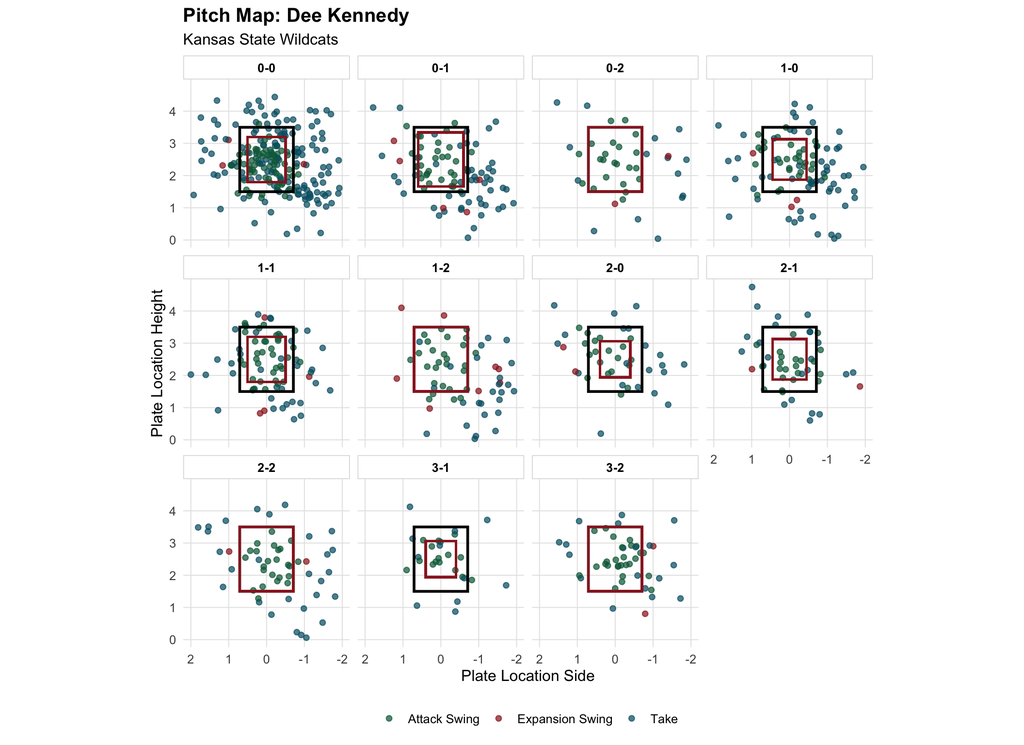

# Project Limitations

This model is designed to evaluate decision quality, not complete hitting ability. A strong decision score means the hitter generally chose appropriate pitches to swing at or take based on count and location. It does not guarantee that the hitter made quality contact, controlled the barrel, or produced positive run value.

Key limitations:

- **Strike-zone assumptions:** The model uses fixed strike-zone boundaries rather than hitter-specific zones. That keeps the method consistent across teams, but it may miss player-specific differences in height, stance, or TrackMan zone calibration.
- **Damage-zone assumptions:** The heart zone is count-adjusted, but the zone shapes and scoring values are still model choices. They are explainable and easy to tune, but they should be reviewed with coaching input.
- **Context not fully modeled:** Pitch type, pitch quality, pitcher handedness, game state, and hitter plan are not directly included in the decision score.
- **OPS is an outcome layer, not the target:** The correlation with OPS is useful validation context, but the decision model should not be expected to fully explain offensive production.
- **P4 vs P4 improves comparability, not perfection:** The P4 vs P4 split controls for competition level better than the full dataset, but it still contains differences in opponent quality, parks, weather, and schedules.
- **Called-zone uncertainty:** Takes near the border can be affected by umpire zone, catcher presentation, and count leverage. The model treats pitch location mechanically.

# Interpretation and Takeaways

The most actionable use of this report is grouping hitters by decision patterns. High-score hitters with low chase rates and strong heart-zone swing rates are strong approach models. Hitters with elevated chase rates may need better pitch-shape recognition or a tighter two-strike plan. Hitters with high heart take rates may need a more aggressive attack plan in counts where damage is available.

This report should be read as a process metric. It does not replace production stats, bat speed, contact quality, or scouting context. Its value is that it shows whether the hitter consistently chose the right pitch to swing at before the result of that pitch entered the evaluation.

| Hitter | Team | Profile | Pitches | Decision Score | Chase% | Heart Swing% | Heart Take% | 2K Score |
| --- | --- | --- | --- | --- | --- | --- | --- | --- |
| Dee Kennedy | Kansas State Wildcats | Selective Attacker | 832 | 1.251201923076923 | 0.2064516129032258 | 0.844 | 0.156 | 1.661971830985915 |
| Armani Guzman | West Virginia Mountaineers | Balanced | 795 | 1.237735849056603 | 0.2526997840172786 | 0.8620689655172413 | 0.1379310344827586 | 1.680288461538461 |
| Yomar Carreras | Rutgers Scarlet Knights | Aggressive Expander | 714 | 1.210084033613446 | 0.3981481481481481 | 0.9293478260869565 | 0.07065217391304347 | 1.236263736263736 |
| Chase Krewson | Rutgers Scarlet Knights | Balanced | 831 | 1.182912154031288 | 0.3023255813953488 | 0.8744186046511628 | 0.1255813953488372 | 1.47071129707113 |
| Owen Hull | North Carolina Tar Heels | Selective Attacker | 881 | 1.175368898978434 | 0.2323809523809524 | 0.8132780082987552 | 0.1867219917012448 | 1.495327102803738 |
| Kolby Branch | Georgia Bulldogs | Balanced | 929 | 1.172766415500537 | 0.2650822669104205 | 0.8730769230769231 | 0.1269230769230769 | 1.424561403508771 |
| Charlie Sutherland | Minnesota Golden Gophers | Balanced | 659 | 1.163884673748103 | 0.2954545454545455 | 0.8707865168539326 | 0.1292134831460674 | 1.497297297297297 |
| Tracer Lopez | Texas Tech Red Raiders | Balanced | 891 | 1.161054994388327 | 0.2859813084112149 | 0.8940677966101694 | 0.1059322033898305 | 1.455156950672646 |
| Brady Neal | Alabama Crimson Tide | Selective Attacker | 795 | 1.159748427672955 | 0.2222222222222222 | 0.815668202764977 | 0.184331797235023 | 1.489177489177489 |
| Daniel Cuvet | Miami Hurricanes | Balanced | 700 | 1.159285714285714 | 0.2699530516431925 | 0.8688524590163934 | 0.1311475409836066 | 1.532608695652174 |

[output cut: 407 more lines]